# Wizualizacja dynamiki

Maciej Beręsewicz

11/22/2016

# Wstęp

Na dzisiejszych zajęciach dowiemy się w jaki sposób wizualizować dynamikę oraz szeregi czasowe. W tym celu posłużymy się zbiorem `apartments` pochodzącym z pakietu `PBImisc` oraz danymi z Badania Kapitału Ludzkiego dotyczącego studentów.

Do wizualizacji dynamiki możemy wykorzystać następujące typy wykresów:

- punktowy – w którym na osi X przedstawimy czas, na osi Y badaną zmienną; wykres ten możemy również wykorzystać do porównania dwóch okresów, gdzie na osi X znajdzie się okres T, a na osi Y okres T+1.
- liniowy – wykres zbliżony do pierwszego typu przy czym punkty łączone są liniami. Wykres ten pozwoli nam również sprawdzić czy występuje autokorelacja w czasie.

# Wizualizacja szeregu czasowego w R

Zaczniemy od wczytania najważniejszych pakietów oraz danych

```r
library('ggplot2') ## wizualizacja danych
library('forecast') ## wizualizacja i przetwarzanie szeregów czasowych
library('zoo') ## dodatkowe ustawienia osi dla szeregów czasowych
library('dplyr') ## przetwarzanie danych
library('tidyr') ## czyszczenie danych
library('PBImisc') ## dane o nieruchomościach
library('scales') ### dodatkowe skale
#devtools::install_github('slowkow/ggrepel') ## developer version
library('ggrepel') ## etykiety do punktów
data("apartments")
```

Przyjrzyjmy się pierwszym wierszom zbioru `apartments`

```r
head(apartments)
```

```
##   year month surface     city    district     street n.rooms floor
## 1 2008     1      20 Warszawa Srodmiescie      Bagno       1     7
## 2 2008     1      25 Warszawa    Pruszkow   Pruszkow       1     1
## 3 2008     1      26 Warszawa     Bielany Marymoncka       1     6
## 4 2008     1      27 Warszawa        Wola     Sienna       1     1
## 5 2008     1      28 Warszawa     Mokotow Raclawicka       1     1
## 6 2008     1      28 Warszawa     Mokotow Miaczynska       2     4
##   construction.date         type offer.price transaction.price m2.price
## 1              1970   hipoteczne          NA            210000    10500
## 2              1965 spoldzielcze          NA            175000     7000
## 3              1964   hipoteczne          NA            218000     8384
## 4              1962 spoldzielcze          NA            230000     8518
## 5              1950   hipoteczne      250000            245000     8750
## 6              1968 spoldzielcze          NA            245000     8750
##    condition      lat      lon
## 1 do remontu 52.22947 21.00761
## 2 do remontu 52.17162 20.80639
## 3 do remontu 52.27114 20.95003
## 4      dobry 52.24238 20.98659
## 5 do remontu 52.19814 21.01752
## 6      dobry 52.19814 21.01752
```

W pierwszej kolejności chcielibyśmy sprawdzić jak zmianiała się liczba obserwacji w badanym okresie.

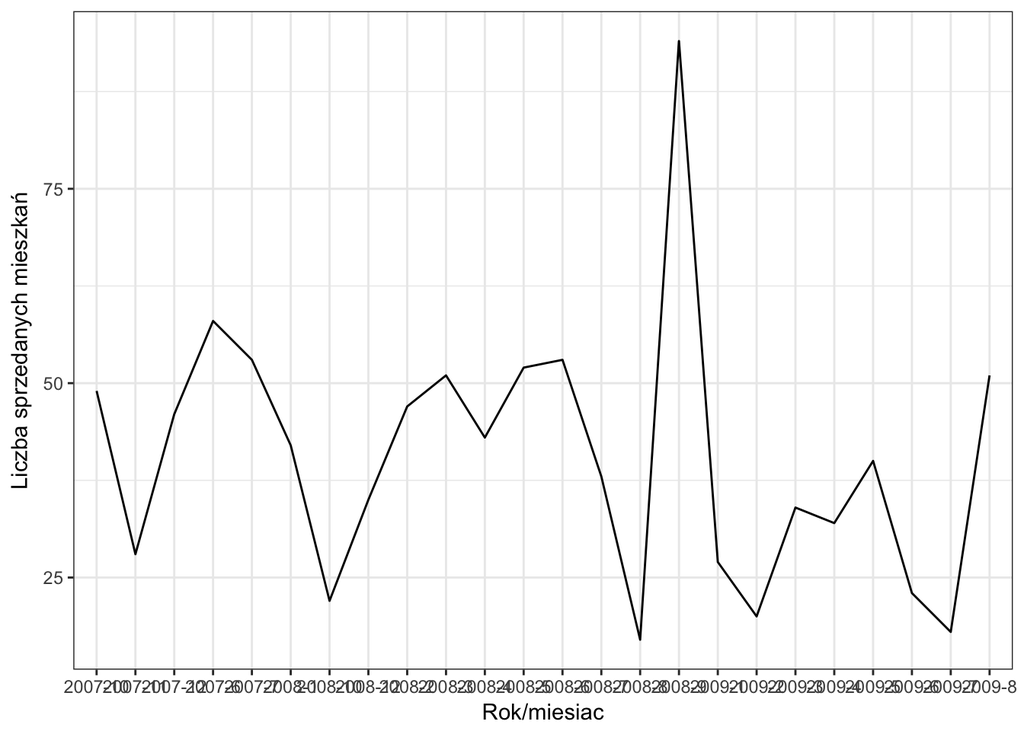

```r
apartments %>%
  count(year, month) %>%
  ggplot(data = .,
         aes(x = paste(year, month, sep = '-'),
          y = n,
          group = 1)) +
  geom_line() +
  theme_bw() +
  xlab('Rok/miesiac') +
  ylab('Liczba sprzedanych mieszkań')
```

Zobaczmy jak wygląda średnia cena mieszkań

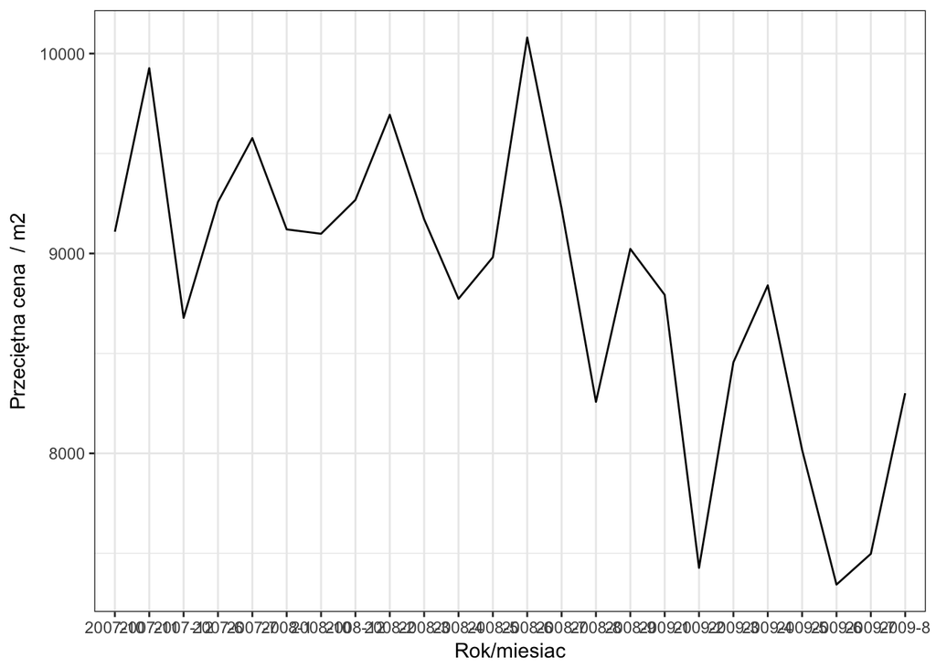

```r
apartments %>%
  group_by(year, month) %>%
  summarise(m = sum(transaction.price)/sum(surface)) %>%
  ggplot(data = .,
         aes(x = paste(year, month, sep = '-'),
          y = m,
          group = 1)) +
  geom_line() +
  theme_bw() +
  xlab('Rok/miesiac') +
  ylab('Przeciętna cena  / m2')
```

Na tym wykresie przedstawiliśmy wartości bezwzględne. Jeżeli chcielibyśmy przedstawić dynamikę powinniśmy odnieść się do okresu początkowego. Jak to zrobić?

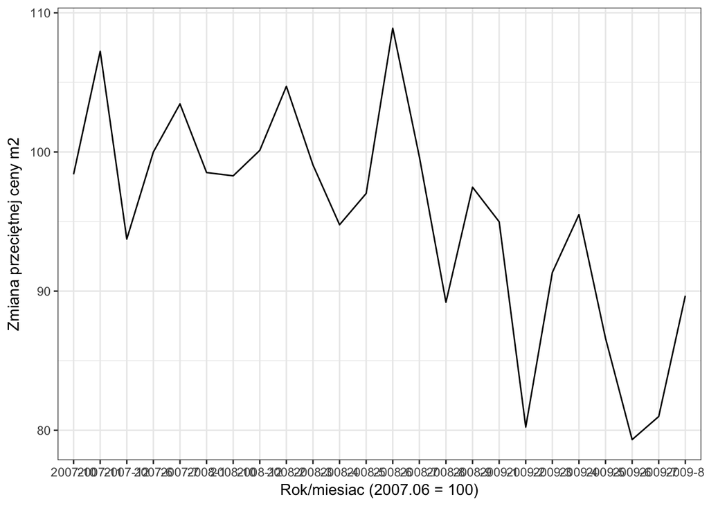

```r
apartments %>%
  group_by(year, month) %>%
  summarise(m = sum(transaction.price)/sum(surface)) %>%
  ungroup() %>%
  mutate(m_dyn = m/.$m[[1]] * 100) %>%
  ggplot(data = .,
         aes(x = paste(year, month, sep = '-'),
          y = m_dyn,
          group = 1)) +
  geom_line() +
  theme_bw() +
  xlab('Rok/miesiac (2007.06 = 100)') +
  ylab('Zmiana przeciętnej ceny m2')
```

## Zapisanie danych w postaci szeregu czasowego

Czy we wszystkich okresach obserwujemy transakcje? Jak to zweryfikować? Możemy do tego użyć funkcji `complete` z pakietu `tidyr`.

```r
szereg <- apartments %>%
  group_by(year, month) %>%
  summarise(m = sum(transaction.price)/sum(surface)) %>%
  ungroup() %>%
  complete(year, month)

szereg %>%
  spread(year, m)
```

```
## # A tibble: 12 × 4
##    month   `2007`    `2008`   `2009`
## *  <int>    <dbl>     <dbl>    <dbl>
## 1      1       NA  9120.456 8793.082
## 2      2       NA  9693.864 7427.338
## 3      3       NA  9170.927 8455.550
## 4      4       NA  8773.203 8840.474
## 5      5       NA  8981.267 8017.360
## 6      6 9257.411 10080.264 7343.636
## 7      7 9576.966  9224.866 7497.543
## 8      8       NA  8257.764 8300.912
## 9      9       NA  9022.826       NA
## 10    10 9108.871  9098.581       NA
## 11    11 9926.910        NA       NA
## 12    12 8678.009  9267.791       NA
```

```r
szereg_ts <- ts(data = szereg$m,
                start = c(2007,1),
                frequency = 12)
print(szereg_ts)
```

```
##            Jan       Feb       Mar       Apr       May       Jun       Jul
## 2007        NA        NA        NA        NA        NA  9257.411  9576.966
## 2008  9120.456  9693.864  9170.927  8773.203  8981.267 10080.264  9224.866
## 2009  8793.082  7427.338  8455.550  8840.474  8017.360  7343.636  7497.543
##            Aug       Sep       Oct       Nov       Dec
## 2007        NA        NA  9108.871  9926.910  8678.009
## 2008  8257.764  9022.826  9098.581        NA  9267.791
## 2009  8300.912        NA        NA        NA        NA
```

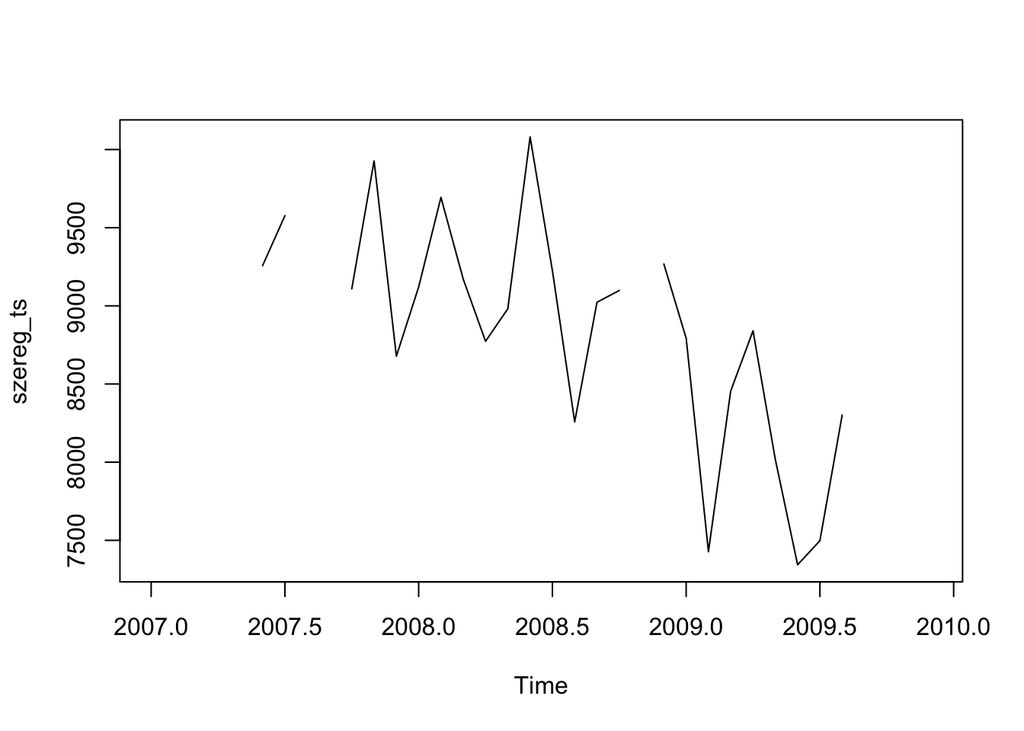

```r
plot(szereg_ts)
```

Co zrobić jeżeli chcielibyśmy przedstawić dane z wykorzystaniem pakietu `ggplot2`?

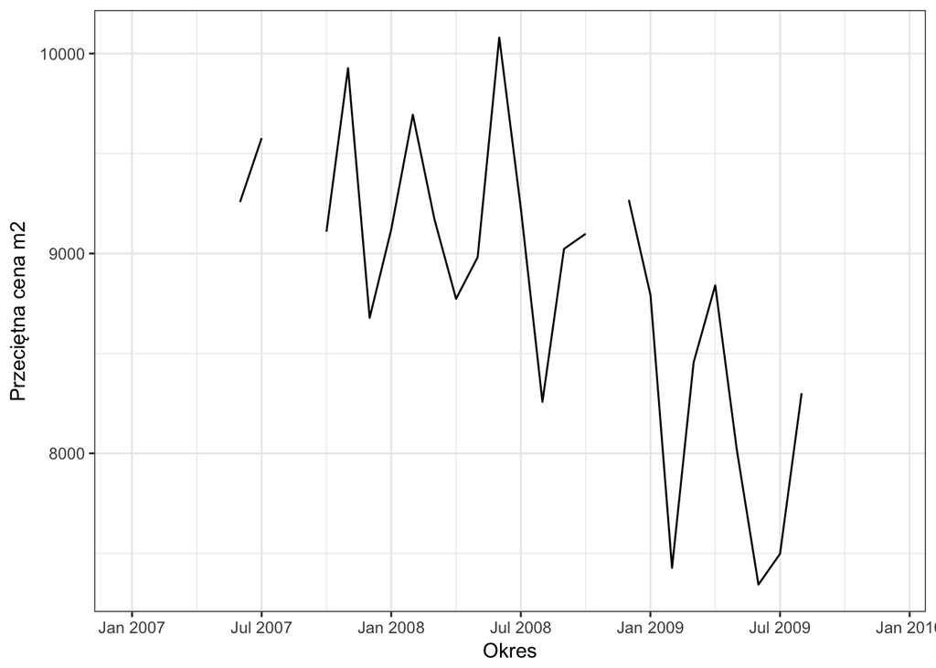

```r
szereg <- szereg %>%
  mutate(ym = paste(year, month, sep = '-'),
         rok_mies = as.yearmon(ym))

ggplot(data = szereg,
       aes(x = rok_mies,
           y = m,
           group = 1)) +
  geom_line() +
  scale_x_yearmon() +
  xlab('Okres') +
  ylab('Przeciętna cena m2') +
  theme_bw()
```

# Porównanie dwóch okresów

Teraz zajmiemy się porównaniem dwóch okresów na podstawie badania studentów w ramach Badania Kapitału Ludzkiego.

```r
dane <- rio::import(file = '../datasets/BKL_studenci_1_4ed.sav')

etyk_E1.1_4 <- attr(dane$E1.1_4,'labels')
etyk_kod_A1_1min <- attr(dane$kod_A1_1min,'labels')

porownanie <- dane %>%
  select(edycja,kod_A1_1min,A2,waga_polaczona,E1.1_4) %>%
  count(edycja,kod_A1_1min,E1.1_4,wt = waga_polaczona) %>%
  na.omit() %>%
  mutate(p= n / sum(n)) %>%
  ungroup() %>%
  mutate( edycja = ifelse(edycja == 0, '2011', '2013'),
          kod_A1_1min = factor(x = kod_A1_1min,
                               levels = as.numeric(etyk_kod_A1_1min),
                               labels = names(etyk_kod_A1_1min)),
          E1.1_4 = factor(x = E1.1_4,
                          levels = as.numeric(etyk_E1.1_4),
                          labels = names(etyk_E1.1_4)))

porownanie
```

```
## # A tibble: 108 × 5
##    edycja  kod_A1_1min        E1.1_4          n           p
##     <chr>       <fctr>        <fctr>      <dbl>       <dbl>
## 1    2011 uniwersytety         niski   91.84516 0.006927913
## 2    2011 uniwersytety    podstawowy  426.65437 0.032182688
## 3    2011 uniwersytety        średni 2337.12728 0.176290327
## 4    2011 uniwersytety        wysoki 5284.18631 0.398588018
## 5    2011 uniwersytety bardzo wysoki 5117.45019 0.386011055
## 6    2011 politechniki         niski   48.62859 0.007007470
## 7    2011 politechniki    podstawowy  127.89984 0.018430602
## 8    2011 politechniki        średni  761.00558 0.109662304
## 9    2011 politechniki        wysoki 2464.28383 0.355107831
## 10   2011 politechniki bardzo wysoki 3537.71885 0.509791793
## # ... with 98 more rows
```

Zobaczmy czy możemy zaobserwować jakieś zmiany w czasie

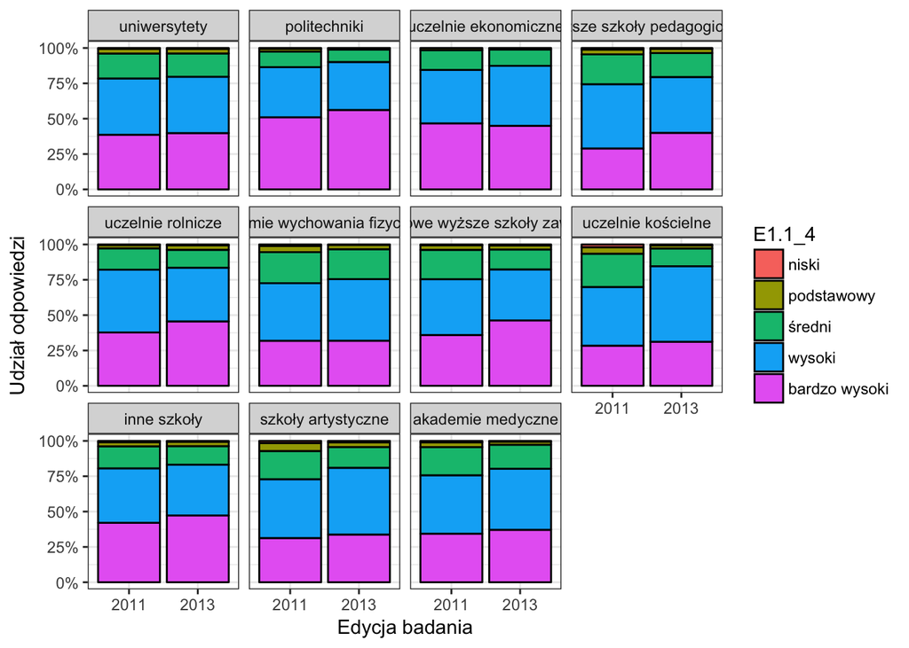

```r
porownanie %>%
  ggplot(data = .,
         aes(x = edycja,
             y = p,
             fill = E1.1_4)) +
  geom_bar(stat = 'identity',
           col = 'black') +
  facet_wrap(~kod_A1_1min) +
  theme_bw() +
  xlab('Edycja badania') +
  ylab('Udział odpowiedzi') +
  scale_y_continuous(labels = percent)
```

Jak możemy przedstawić to inaczej? Spróbujmy wykres rozrzutu!

## Wykres rozrzutu

Dane do wykresu musimy trochę przetworzyć

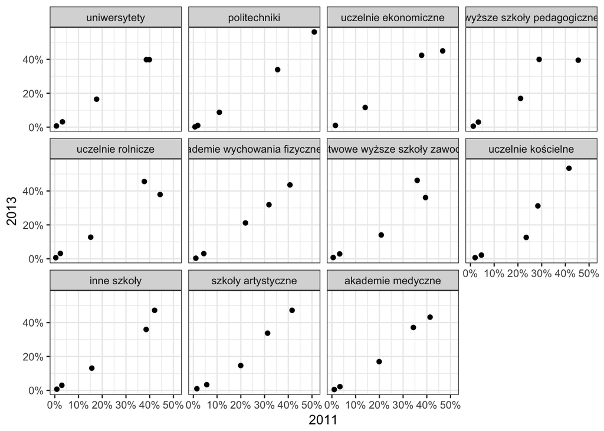

```r
por_wyk <- porownanie %>%
  select(-n) %>%
  spread(edycja, p)

wykres_por <- por_wyk %>%
  ggplot(data = .,
         aes(x = `2011`,
             y = `2013`,
             group = E1.1_4)) +
  geom_point() +
  facet_wrap(~kod_A1_1min) +
  scale_y_continuous(labels = percent) +
  scale_x_continuous(labels = percent) +
  theme_bw()

wykres_por
```

Co możemy jeszcze zrobić z tym wykresem?

Dodajmy:

- przekątną
- etykiety do punktów

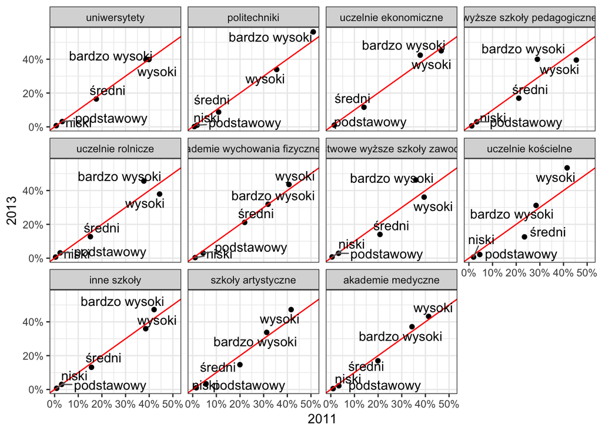

```r
wykres_por +
  geom_abline(slope = 1, intercept = 0, col = 'red') +
  geom_text_repel(aes(label = E1.1_4))
```

Co widzimy na tym wykresie? Porównajmy teraz uczelnie dla poziomu `wysokiego` i `bardzo wysokiego`.

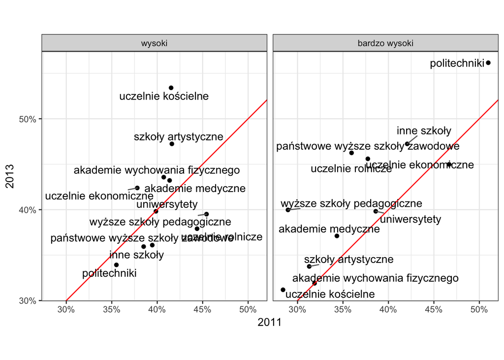

```r
por_wyk %>%
  filter(E1.1_4 %in% c('wysoki','bardzo wysoki')) %>%
  ggplot(data = .,
         aes(x = `2011`,
             y = `2013`,
             group = kod_A1_1min)) +
  geom_point() +
  facet_wrap(~ E1.1_4) +
  scale_y_continuous(labels = percent) +
  scale_x_continuous(labels = percent) +
  theme_bw()  +
  geom_abline(slope = 1, intercept = 0, col = 'red') +
  geom_text_repel(aes(label = kod_A1_1min)) +
  coord_fixed()
```